# Data Processing for AZD1222 Stage 2 Correlates

### Data descriptives

The dataset contains both treatment arms and both seropos and seroneg, and has US, CHL and PERU. Only the vaccine arm is sampled in stage 2.

### Phase 2 sampling design

- Cases are vaccine group participants who contribute primary COVID-19 endpoints, i.e. baseline SARS-CoV-2 negative and SARS-CoV-2 negative for 15 days post-second dose, adjudicated COVID-19) with COVID-19 onset 7+ days post-Day 57 through D360.
  - COVIDIndD57_7toD360
- All severe COVID-19 cases satisfying these criteria are sampled.
  - SevereCOVIDIndD57_7toD360
- Sampling of non-severe COVID-19 cases satisfying these criteria is stratified into 6 strata (by baseline age, country, and race/ethnicity) and virus lineage (Delta, ancestral, others). For each baseline stratum, stratified sampling is based on quartiles.
  - KnownOrImputedDeltaCOVIDIndD57_7toD360
  - DeltaCOVIDIndD57_7toD360

``Non-cases" are baseline SARS-CoV-2 negative vaccine group participants without any SARS-CoV-2 infection (no positive serology result or COVID-19) and without documented outside COVID-19 vaccination from Day 1 through D360 or the study termination date, whichever earlier, and with a follow up end date after 7 days post Day 57, sampled from the Stage 1 immunogenicity subcohort, achieving 1:1 case:control ratio overall; no case/control matching is performed due to sample availability. To ensure complete longitudinal data for exposure-proximal correlates analysis, non-cases are also required to have D57, D90, D180, and D360 visits to be eligible for sampling.

Number of severe cases in ph1 and ph2

```r
with(subset(dat_mapped, EarlyinfectionD57==0 & Perprotocol==1 & Bserostatus==0 & Trt==1), mytable(!is.na(Day57bindSpike_Delta3), SevereEventIndD57_120to21Dec10))
```

```
##        SevereEventIndD57_120to21Dec10
##             0     1  <NA>
##   FALSE 13017     3  3675
##   TRUE    183    20    32
```

Number of Delta cases in D57_120to21Dec10 in ph1 and ph2

```r
with(subset(dat_mapped, EarlyinfectionD57==0 & Perprotocol==1 & Bserostatus==0 & Trt==1), mytable(!is.na(Day57bindSpike_Delta3), DeltaEventIndD57_120to21Dec10))
```

```
##        DeltaEventIndD57_120to21Dec10
##             0     1  <NA>
##   FALSE 12762   258  3675
##   TRUE    143    60    32
```

Distributions of sampling weights:

```r
with (subset(dat_proc, ph2.D57nAb==1 & Trt==1 & Bserostatus==0), table(ph2.D57nAb, Wstratum))
```

```
##           Wstratum
## ph2.D57nAb 13 14 15 16 17 18 19 20
##       TRUE 42 25 44 21 20  4 46 18
```

```r
with (subset(dat_proc, ph2.D57bAb==1 & Trt==1 & Bserostatus==0), table(ph2.D57bAb, Wstratum))
```

```
##           Wstratum
## ph2.D57bAb 13 14 15 16 17 18 19 20
##       TRUE 48 24 41 23 21  4 52 22
```

### Adjusting endpoint period

Distribution of event time by variant types. Ph2 cases are colored green and severe cases are colored red.

We chose 119/120 days post D57 to break the follow-up period into two because all Delta cases and all but two severe cases happened after that. 120 days post D57 is the first Delta case, on 2021-07-02.

We censor on 2021-12-10 to avoid the Omicron wave, the same day the PREVENT-19 stage2 data is censored on as well. We lose no severe cases by this censoring.

```r
dat.tmp=subset(dat_mapped, EarlyinfectionD57==0 & Perprotocol==1 & Bserostatus==0 & Trt==1)
print(min(subset(dat.tmp,EventIndPrimaryType_short=="Del",EventTimePrimaryD57),na.rm=T))
```

```
## [1] 120
```

```r
subset(dat.tmp,EventIndPrimaryType_short=="Del" & EventTimePrimaryD57==120, EventCalTimePrimaryD57)
```

```
##      EventCalTimePrimaryD57
## 4862             2021-07-02
```

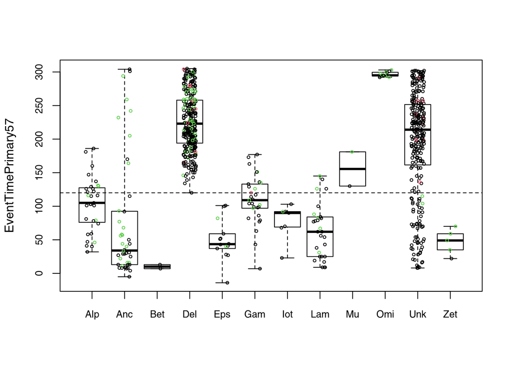

```r
# D57 study day
myboxplot(EventTimePrimaryD57~EventIndPrimaryType_short, dat.tmp, ylab="EventTimePrimary57", col=dat.tmp$col, cex.axis=0.8)
abline(h=120, lty=2)
```

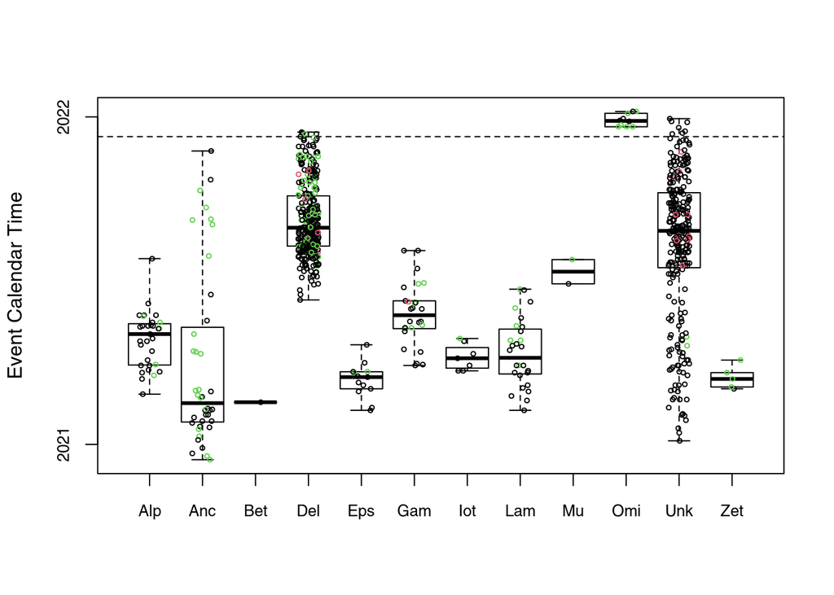

```r
# calendar day
myboxplot(EventCalTimePrimaryD57~EventIndPrimaryType_short, dat.tmp, ylab="Event Calendar Time", col=dat.tmp$col, cex.axis=0.8)
abline(h=120, lty=2)
abline(h=as.Date("2021-12-10"), lty=2)
```

```r
# subset(dat_mapped,EventIndPrimaryType_short=="Del" & as.Date(DateDD1)<as.Date("2021-01-01"), c(Subjectid, EventTimePrimaryDate, DateDD1))
```

### Immunogenecity and imputation

Verifying marker values are subject to lower limits

```r
print(sort(unique(dat_mapped$Day57pseudoneutid50_D614G))[1:5])
```

```
## [1] 0.1159432 0.4276970 0.4381625 0.4483816 0.4583659
```

```r
print(sort(unique(dat_mapped$Day57pseudoneutid50_Delta))[1:5])
```

```
## [1] 0.1159432 0.4276970 0.4381625 0.4483816 0.4583659
```

The following plot shows that Delta ID50 readouts are lower than ancestral ID50 and that marker level drops from over time. All cases are colored red.

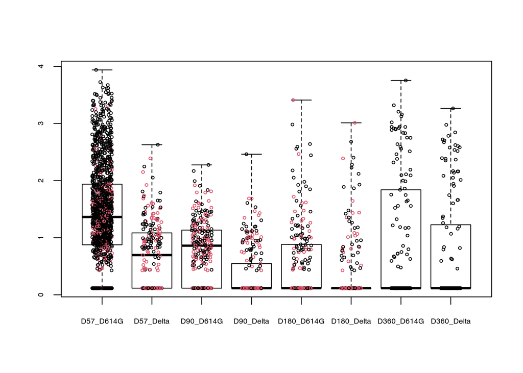

```r
dat=dat_mapped[,c(rbind(times%.%"pseudoneutid50_D614G",times%.%"pseudoneutid50_Delta"))]
names(dat)=sub("pseudoneutid50","",names(dat))
names(dat)=sub("Day","D",names(dat))
myboxplot(dat, cex.axis=0.6, col=dat_mapped$col2)
```

Correlation is high between bAb markers (0.99 between the three Delta bAb markers), but moderate between the two nAb markers.

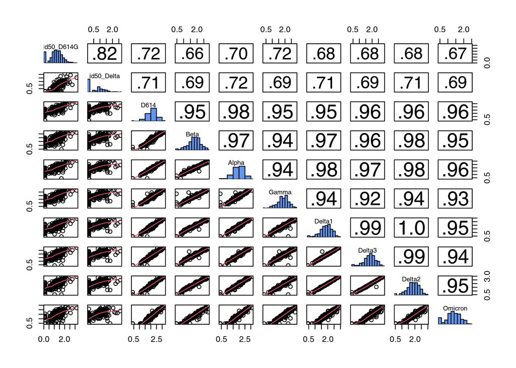

```r
dat=subset(dat_mapped, EarlyinfectionD57==0 & Perprotocol==1 & Bserostatus==0 & Trt==1)
dat=dat[,"Day57"%.%assays]
names(dat)=sub("Day57pseudoneut","",names(dat))
names(dat)=sub("Day57bindSpike_","",names(dat))
mypairs(dat)
```

A closer look at the correlation between ancestral ID50 and Delta ID50

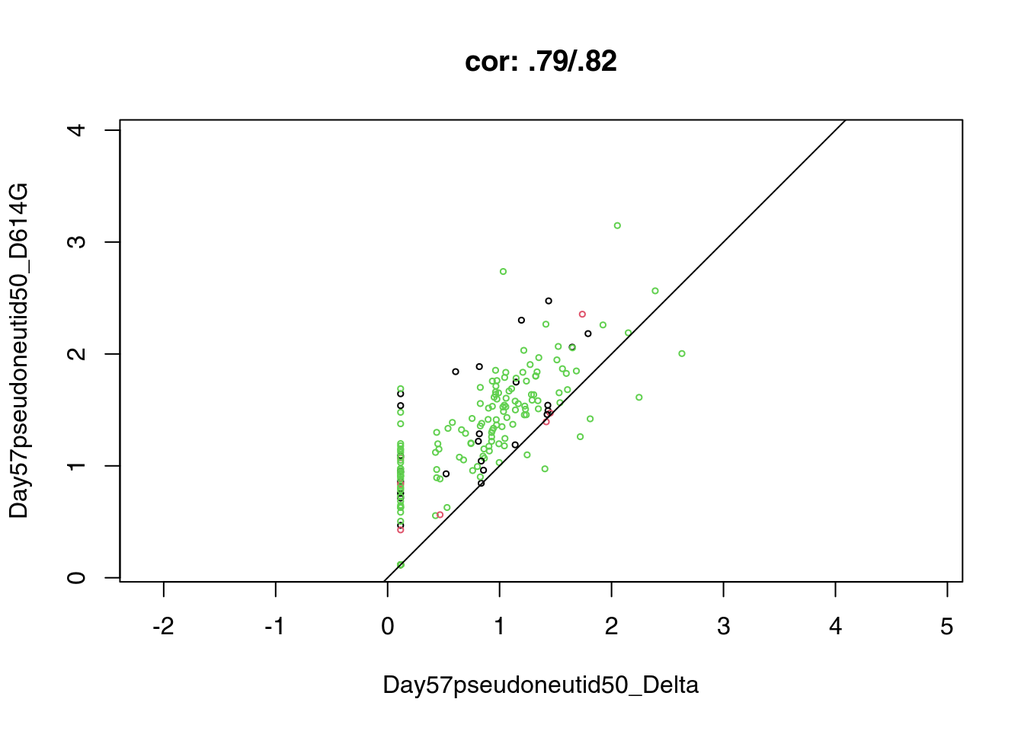

```r
corplot(Day57pseudoneutid50_D614G~Day57pseudoneutid50_Delta, dat_mapped, asp=1)
```

bAb markers are all-or-none.

```r
dat=subset(dat_mapped, EarlyinfectionD57==0 & Perprotocol==1 & Bserostatus==0 & Trt==1)
for (i in 1:length(assays)) {
  dat[['tmp'%.%i]]=ifelse(is.na(dat[['Day57'%.%assays[i]]]), 0, 1)
}
dat$tmp=with(dat,paste0(tmp1,tmp2,tmp3,tmp4,tmp5,tmp6,tmp7,tmp8,tmp9,tmp10))
print(table(dat$tmp, dat$DeltaEventIndD57_120to21Dec10))
```

```
##
##                  0     1
##   0000000000 12378   250
##   0011111111     6     4
##   0111111111     7     5
##   1000000000   367     5
##   1011111111    17     7
##   1100000000    17     3
##   1111111111   113    44
```

We will only impute ancestral ID50 using Delta ID50. We will have two sets of weights, one for bAb and one for nAb.

```r
dat=subset(dat_mapped)
dat$tmp1 = !is.na(dat$Day57pseudoneutid50_Delta)
dat$tmp2 = !is.na(dat$Day57bindSpike_Alpha)
dat$tmp=with(dat,paste0(as.integer(tmp1),as.integer(tmp2)))
print(table(dat$tmp, dat$DeltaEventIndD57_120to21Dec10))
```

```
##
##          0     1
##   00 14894   278
##   01    23    11
##   10    17     3
##   11   120    50
```

```r
dat=subset(dat_mapped, ph1.D57==1)
dat$tmp1 = !is.na(dat$Day57pseudoneutid50_Delta)
dat$tmp2 = !is.na(dat$Day57bindSpike_Alpha)
dat$tmp=with(dat,paste0(as.integer(tmp1),as.integer(tmp2)))
print(table(dat$tmp, dat$DeltaEventIndD57_120to21Dec10))
```

```
##
##          0     1
##   00 14704   276
##   01    23    11
##   10    17     3
##   11   120    49
```

### Covariates adjustment

We will **adjust for Age in severe COVID correlates analyses**.

```r
coxph(Surv(SevereEventTimeD57_to21Dec10, SevereEventIndD57_120to21Dec10)~Age+risk_score, subset(dat_proc, ph1.D57_120==1 & Bserostatus==0 & Trt==1))
```

```
## Call:
## coxph(formula = Surv(SevereEventTimeD57_to21Dec10, SevereEventIndD57_120to21Dec10) ~
##     Age + risk_score, data = subset(dat_proc, ph1.D57_120 ==
##     1 & Bserostatus == 0 & Trt == 1))
##
##               coef exp(coef) se(coef)     z      p
## Age        0.03598   1.03663  0.01538 2.339 0.0193
## risk_score 0.43607   1.54662  0.86498 0.504 0.6142
##
## Likelihood ratio test=6.22  on 2 df, p=0.04463
## n= 13100, number of events= 23
##    (6 observations deleted due to missingness)
```

```r
coxph(Surv(SevereEventTimeD57_to21Dec10, SevereEventIndD57_120to21Dec10)~Senior+risk_score, subset(dat_proc, ph1.D57_120==1 & Bserostatus==0 & Trt==1))
```

```
## Call:
## coxph(formula = Surv(SevereEventTimeD57_to21Dec10, SevereEventIndD57_120to21Dec10) ~
##     Senior + risk_score, data = subset(dat_proc, ph1.D57_120 ==
##     1 & Bserostatus == 0 & Trt == 1))
##
##              coef exp(coef) se(coef)     z      p
## Senior     0.7462    2.1090   0.4535 1.645 0.0999
## risk_score 0.3343    1.3969   0.8062 0.415 0.6784
##
## Likelihood ratio test=2.53  on 2 df, p=0.2829
## n= 13100, number of events= 23
##    (6 observations deleted due to missingness)
```

We will **adjust for Age>=65 in Delta COVID correlates analyses**. Age group is a stratification variable of the randomization and adjusted for in the primary efficacy analysis. Furthermore, nonparametric risk estimate shows that the risk as a function of age is a step function with change point at 65.

```r
coxph(Surv(DeltaEventTimeD57_to21Dec10, DeltaEventIndD57_120to21Dec10)~Age+risk_score, subset(dat_proc, ph1.D57_120==1 & Bserostatus==0 & Trt==1))
```

```
## Call:
## coxph(formula = Surv(DeltaEventTimeD57_to21Dec10, DeltaEventIndD57_120to21Dec10) ~
##     Age + risk_score, data = subset(dat_proc, ph1.D57_120 ==
##     1 & Bserostatus == 0 & Trt == 1))
##
##                 coef exp(coef)  se(coef)      z        p
## Age        -0.005823  0.994194  0.003804 -1.531    0.126
## risk_score  1.454576  4.282669  0.267054  5.447 5.13e-08
##
## Likelihood ratio test=44.51  on 2 df, p=2.166e-10
## n= 13100, number of events= 317
##    (6 observations deleted due to missingness)
```

```r
coxph(Surv(DeltaEventTimeD57_to21Dec10, DeltaEventIndD57_120to21Dec10)~Senior+risk_score, subset(dat_proc, ph1.D57_120==1 & Bserostatus==0 & Trt==1))
```

```
## Call:
## coxph(formula = Surv(DeltaEventTimeD57_to21Dec10, DeltaEventIndD57_120to21Dec10) ~
##     Senior + risk_score, data = subset(dat_proc, ph1.D57_120 ==
##     1 & Bserostatus == 0 & Trt == 1))
##
##               coef exp(coef) se(coef)      z        p
## Senior     -0.5278    0.5899   0.1828 -2.887  0.00389
## risk_score  1.3013    3.6739   0.2640  4.929 8.28e-07
##
## Likelihood ratio test=51.5  on 2 df, p=6.545e-12
## n= 13100, number of events= 317
##    (6 observations deleted due to missingness)
```